# Unpacking the Drivers of Volatility: An Empirical Study

Christian Guallpa

Ongoing Process

# Abstract

The study aims to investigate the various quantitative factors that may impact the volatility of the stock market, with a specific focus on the two prominent corporations, Apple and Google. The study is important as understanding stock price volatility can help investors manage risk and make informed decisions regarding their investment strategies.

To investigate the impact of external factors on a company’s stock price volatility, a GARCH(1,1) model will be used to model the volatility of the stock price. The GARCH model is a statistical approach that assumes volatility is time-varying and is influenced by past shocks. Once a baseline model is developed, external regressors such as economic indicators or relevant financial data will be incorporated to capture additional information that may influence volatility. The formula will be modified to account for the influence of the external regressors. The effectiveness of the external regressors will be evaluated by comparing the accuracy of the GARCH model with the added regressors to that of the original GARCH model. If the coefficients of the external regressors are statistically significant, they will be considered as possible factors that contribute to volatility. The accuracy of the GARCH model with the added regressors will be evaluated by analyzing and comparing their respective average residuals to the actual number. In addition to the primary analysis, an additional test will be conducted to validate the effect observed using a linear regression model. This test aims to provide further evidence and enhance the reliability of the findings. By employing a linear regression approach, the study seeks to establish a quantitative relationship between the identified factors and stock price volatility, offering a more rigorous evaluation of the effect’s validity. Through this statistical analysis, the study aims to assess the strength and significance of the observed relationships, providing a robust framework for understanding the impact of the factors on volatility.

By the end, the study sheds light on the impact of external factors on the volatility of a company’s stock price. The results demonstrate that inflation, interest rate, and unemployment are clear factors that affect the volatility of the stock price. The analysis also suggests that the country’s GDP, the company’s debt-to-equity ratio, and price-to-earnings ratio are additional factors that could impact the stock price volatility. Although the study has tested a variety of factors, there may be other unexplored factors that could also affect the company’s volatility. Therefore, further research is necessary to understand the complete picture of the drivers of volatility.

Investors should exercise caution and recognize that despite the study shedding light on the factors that influence volatility, the stock market remains inherently unpredictable. While the study provides valuable insights into potential drivers of volatility, it is important to remember that stock prices can be influenced by a multitude of unpredictable events, market sentiments, and unforeseen circumstances. Therefore, investors should approach their investment decisions with a comprehensive understanding of the risks involved, conduct thorough research, and diversify their portfolios to manage uncertainties effectively

**Note: I could perhaps include the inflation rate graph as proof here. However the purpose of the study is to outline possible factors to the change of volatility, so perhaps more graphs can be included here besides the inflation one**

# Table of Contents

Abstract 1  
1. Introduction 4  
1.1 Background 4  
1.2 Purpose 5  
2. Data Exploration 5  
2.1 Data Collection 5  
2.2 Data Description 5  
2.3 Exploratory Analysis 6  
3. Data Analysis 6  
3.1 Method 6  
3.2 Pre-Analysis 8  
3.3 Analysis 9  
3.3.1 Inflation Rate 9  
3.3.2 Unemployment Rate 11  
3.3.3 Interest Rate 13  
3.4 Observations 15  
3.4.1 Gross Domestic Product 15  
3.4.2 Debt-to-Equity Ratio 16  
3.4.3 Price-to-Earnings Ratio 16  
4. Discussion 17  
4.1 Findings 17  
4.2 Limitations 18  
5. Conclusion 19  
6. References 21  
7. Appendix 21  
7.1 Appendix A: Data Dictionary 21  
7.2 Appendix B: Graphical Displays for Google 25

# 1. Introduction

# 1.1 Background

Investing is a difficult task that requires knowledge, experience, and careful decision-making. There are many factors that contribute to the complexity of investing, including the unpredictability of financial markets and the constantly changing economic landscape. Investors must also be able to analyze and interpret vast amounts of data to identify opportunities and assess risk. Additionally, investing always carries some degree of risk. Even the most well-researched investment can be impacted by unforeseeable events, such as economic downturns, geopolitical unrest, or natural disasters. Investors must accept this risk and be prepared to adapt their strategies accordingly. Furthermore, investing involves trade-offs between potential returns and risk, as higher-risk investments may offer the potential for greater returns but also carry a higher risk of losses. Therefore, investors must be cautious and diversify their portfolios to mitigate risk and achieve their long-term goals.

However, one way investors can combat these financial risks is by understanding volatility. It is crucial for investors as it enables them to make more informed investment decisions and potentially achieve better results. By comprehending the level of volatility associated with different assets, investors can assess the risk-reward trade off more effectively. Higher volatility assets typically offer the potential for greater returns, but they also come with a higher level of risk. Conversely, lower volatility assets tend to be more stable but may offer relatively modest returns. By understanding the volatility of various investments, investors can align their choices with their risk tolerance, investment objectives, and time horizons. This knowledge allows for the construction of well-balanced portfolios that can withstand market fluctuations. Moreover, understanding volatility helps investors to manage their expectations. They can anticipate and mentally prepare for potential price swings, minimizing the impact of short-term market fluctuations on their long-term investment strategy. Additionally, understanding volatility allows investors to fine-tune their risk management strategies. By diversifying their portfolios across different asset classes with varying levels of volatility, investors can reduce overall risk and potentially enhance returns. Overall, a thorough understanding of volatility empowers investors to make more informed decisions, manage their portfolios effectively, and set realistic expectations, leading to better investment outcomes over the long run.

# 1.2 Purpose

As a result, the study aims to explore multiple quantitative factors that could potentially influence the volatility of the stock market. In addition, it seeks to analyze the relationship between a company’s financial performance and the volatility of its stock price. The focus of the study will be on two well-known corporations, namely Apple and Google.

# 2. Data Exploration

# 2.1 Data Collection

The data was collected from two primary sources: Yahoo Finance and FRED (Federal Reserve Economic Data). Yahoo Finance was used to gather financial data on individual companies (specifically Apple and Google), including stock prices, historical data, and financial statements. To collect the data, the search function was used to find the relevant company or stock, and then the data was extracted from the historical data or financial statements section of the website.

FRED was used to collect economic data on a variety of indicators, including inflation rates, unemployment data, and GDP growth. The search function was used to find the relevant economic indicator, and then the relevant data series was accessed.

Both Yahoo Finance and FRED are considered reliable sources of financial and economic data. Yahoo Finance’s data is sourced from reputable providers such as Morningstar, S&P Global Market Intelligence, and Refinitiv, while FRED’s data is provided by the Federal Reserve Bank of St. Louis, which is a highly trusted source of economic data.

# 2.2 Data Description

The consolidation of data involves the combination of financial statements (income statement, balance sheet, cash flow) for each company. The focus is on specific variables, such as net income, total debt, and stockholder’s equity. Historical stock price data, including high, low, and volume information, is available for each company starting from January 5, 2006. However, for the volatility analysis, the adjusted close stock price will be used. In addition, there is access to daily inflation rates and the dollar index, along with other economic indicators. The GDP and the country’s total debt were recorded quarterly, while the interest rates and unemployment rates were recorded monthly, both dating back to January 01, 2005..

For definitions and ranges of variables, see the Appendix 1: Data Dictionary

# 2.3 Exploratory Analysis

To investigate the volatility change of the two companies, it is necessary to observe the relative trends of each company’s daily adjusted close stock price before any analysis.

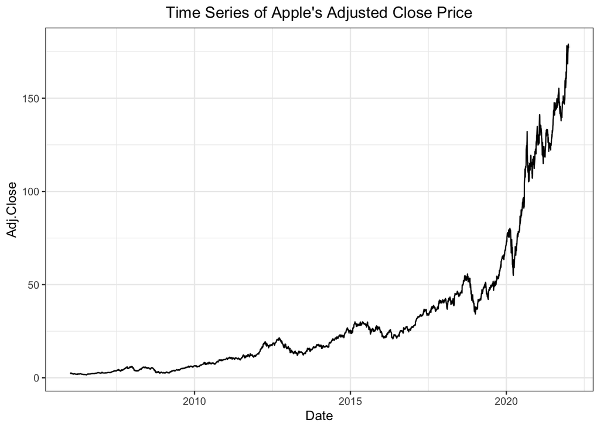

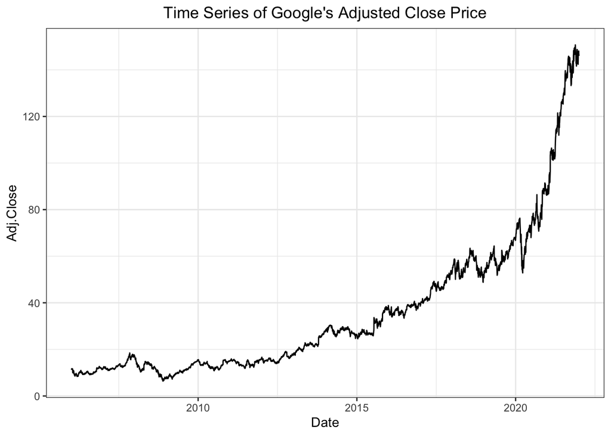

Through an examination of the two graphs, a consistent trend is evident among both companies. Notably, despite the initial impact of the COVID-19 pandemic in 2020, which caused a recession, both companies experienced a steady increase in their stock prices, with one outperforming the other in certain years.

# 3. Data Analysis

# 3.1 Method

For this analysis, the objective is to examine the influence of external factors, such as economics indicators, on the volatility of the company’s stock price. The initial approach involves modeling the stock price volatility using a GARCH model.

The GARCH (Generalized Auto regressive Conditional Heteroskedasticity) model is a statistical approach used to analyze and predict the volatility of financial assets. The model assumes that volatility is time-varying and that it is influenced by past shocks. The study will use the GARCH(1,1) model, which is one of the most commonly used GARCH models. The 1,1 in the model’s name refers to the order of the auto regressive and moving average components in the mean equation and the order of the auto regressive component in the variance equation, respectively. As a result GARCH model does have two components: the mean equation and the variance equation. The mean equation specifies how the conditional mean of the asset price changes over time, while the variance equation describes how the conditional variance of the asset price changes over time.

Mean Equation: $r_t = \mu + \epsilon_t$, where $r_t$ is the log return of the asset at time $t$, $\mu$ is the constant mean of the asset returns, and $\epsilon_t$ is the residual or error term, which follows a normal distribution with a mean of zero and a constant variance.

Variance Equation: $\sigma_t^2 = \omega + \alpha\epsilon_{t - 1}^2 + \beta\sigma_{t - 1}^2$, where $\sigma_t^2$ is the conditional volatility (referred to as “conditional” because it is estimated based on the past values of the error term and its variance, as well as other information that is available up to that point in time) at time $t$, $\omega$ is the constant (>0) variance of the asset returns, $\alpha$ ($\geq 0$) is the coefficient of the lagged squared residual term $\epsilon_{t-1}^2$, and $\beta$ ($\geq 0$) is the coefficient of the lagged conditional variance term $\sigma_{t-1}^2$.

The GARCH model’s coefficients, $\alpha$ and $\beta$, have distinct interpretations. The $\alpha$ coefficient reflects the magnitude of volatility’s response to unexpected returns or shocks, whereas the $\beta$ coefficient reflects the persistence of volatility, or how long it takes to revert back to long-run volatility. Typically, the sum of these coefficients, $(\alpha + \beta)$, is less than one.

Before modeling the log returns using a simple GARCH model, it is important to verify whether the given data satisfies the two conditions for GARCH: volatility clustering and the ARCH effect (presence of conditional heteroscedasticity, i.e., non-constant variance). This analysis will allow for the estimation of the conditional variance of the asset returns and the ability to forecast future volatility. Once a baseline model has been developed, the incorporation of external regressors will be considered. These external variables could comprise of economic indicators or other relevant financial data that might affect asset volatility. The inclusion of these external regressors aims to capture additional information that could potentially impact volatility.

Incorporating the external regressor in the variance equation allows for the consideration of its influence, leading to the following outcome:

Variance Equation: $\sigma_t^2 = \omega + \alpha\epsilon_{t - 1}^2 + \beta\sigma_{t - 1}^2 + \gamma x_{t-1}^2$, where $x_{t-1}$ is the value of the external regressor at time $t-1$, and $\gamma$ is the estimated coefficient of the external regressor.

It is noteworthy that while the models that exhibit statistically significant coefficients for external regressors may not show much improvement, which can be attributed to the considerable capabilities of the GARCH model. It is possible that the effect of the external regressors is already accounted for by the lagged values of the conditional variance and squared errors in the GARCH model. Nonetheless, for the study, the aim is to identify a few factors that may have an impact on volatility. Therefore, if the coefficients are statistically significant, they will be considered as possible factors that contribute to volatility. In addition, to evaluate the effectiveness of the external regressors, the accuracy of the GARCH model with the added regressors will be compared to that of the original GARCH model. This will be done by analyzing and comparing their respective average residuals to the actual number.

More information can be found at [“Forecasting Volatility Using GARCH Models” written by Francisco Costa](https://core.ac.uk/download/pdf/132797589.pdf)

# 3.2 Pre-Analysis

To conduct a preliminary analysis, it is crucial to verify whether the GARCH model fulfills two essential criteria: volatility clustering and the ARCH effect. To ensure the correct application of the GARCH model, the following checks will be performed for each company. Firstly, a plot of the log returns will be generated, derived from the computation of the differences between the logarithmic adjusted closing stock prices of each company over time. This examination will help ascertain the presence of volatility clustering.

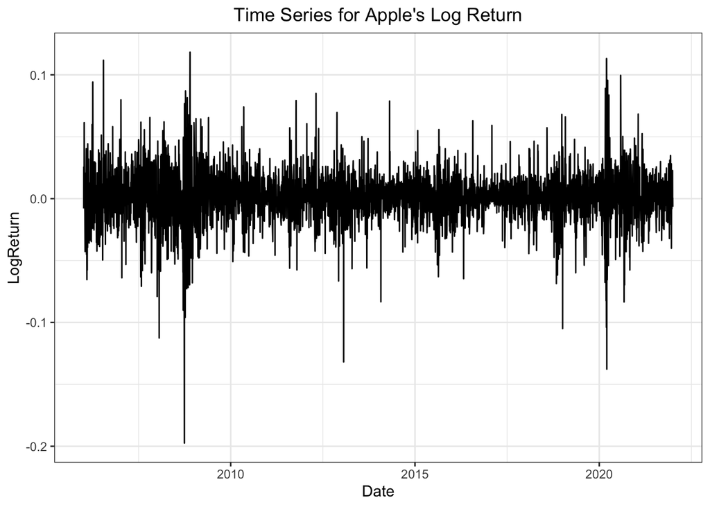

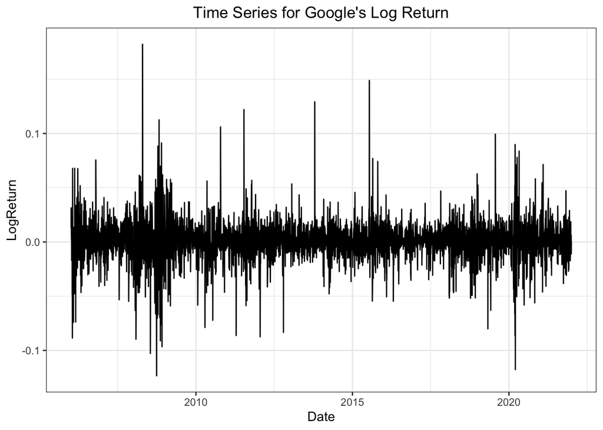

Upon analyzing the graphs, it becomes evident that the GARCH model meets the criterion of volatility clustering. This is evident as significant changes are consistently followed by substantial changes, while minor changes are consistently followed by modest changes as well.

Next, an examination will be conducted to assess the fulfillment of the ARCH effect condition.

```
##
##  ARCH LM-test; Null hypothesis: no ARCH effects
##
## data:  apple_stock$LogReturn
## Chi-squared = 477.56, df = 12, p-value < 2.2e-16
```

```
##
##  ARCH LM-test; Null hypothesis: no ARCH effects
##
## data:  google_stock$LogReturn
## Chi-squared = 204.53, df = 12, p-value < 2.2e-16
```

The test results indicate that the p-value for both cases is less than 0.05, which confirms the presence of the ARCH effect.

# 3.3 Analysis

Once the prerequisites for modeling the GARCH model have been confirmed, the subsequent step involves implementing the GARCH model for each company. This will allow for testing whether any external factors exert an influence on the volatility changes..

Graphical displays and outcomes are solely for Apple. For Google’s graphical displays and outcomes, see the Appendix 2: Graphical Displays for Google

To begin, by utilizing the “rugarch” library in R and including only the coefficients that are statistically significant at 0.05, I obtain the subsequent equations for each company (without any external factors).

**Apple:**

$\sigma_t^2 = 0.000013 + 0.100249(\epsilon_{t-1}^2) + 0.869840(\sigma_{t-1}^2)$, having an average of residuals of $-0.00081$

**Google:**

$\sigma_t^2 = 0.000011 + 0.076529(\epsilon_{t-1}^2) + 0.891138(\sigma_{t-1}^2)$, having an average of residuals of $-0.00025$

At this stage, an analysis will be presented regarding various factors that have displayed statistical significance in influencing the volatility of each company.

# 3.3.1 Inflation Rate

Inflation was identified as one of the factors that has a significant influence on volatility. The p-values of each company confirmed statistical significance. While the formulas changed with the addition of the inflation external factor, where previously significant coefficients may no longer be significant when the coefficient of the external regressor becomes significant, the accuracies remained consistent, as demonstrated below,

**Apple:**

$\sigma_t^2 = 0.099359(\epsilon_{t-1}^2) + 0.870555(\sigma_{t-1}^2) + 0.000003(x_{t-1}^2)$, having an average of residuals of $-0.00081$

**Google:**

$\sigma_t^2 = 0.075265(\epsilon_{t-1}^2) + 0.893809(\sigma_{t-1}^2) + 0.000004(x_{t-1}^2)$, having an average of residuals of $-0.00026$

To visualize the relationship, the figure for Apple below demonstrates that whenever there is a significant decrease in inflation, the volatility tends to react in the opposite direction significantly.

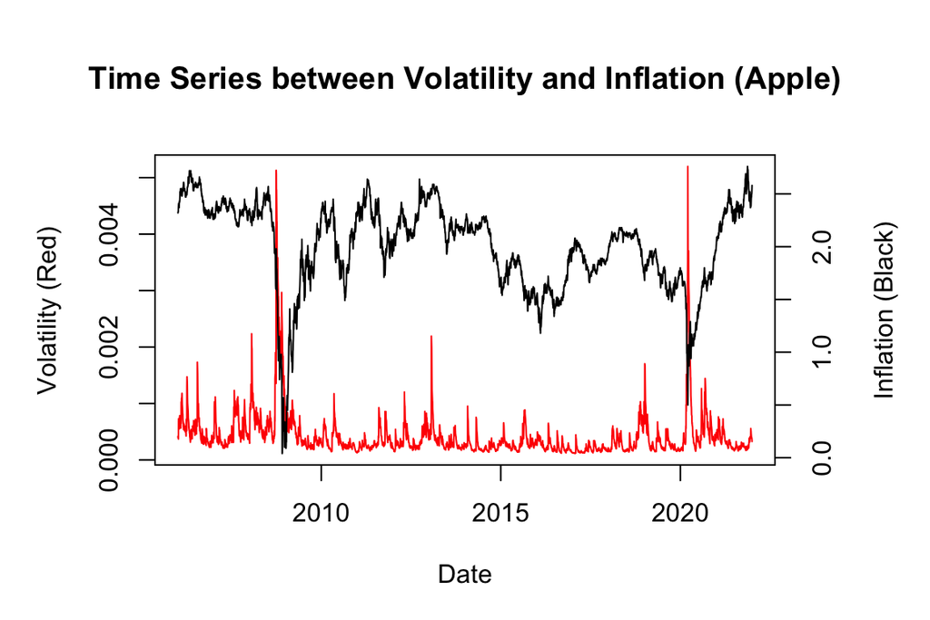

Besides the evident impact of inflation on the GARCH model, an alternative approach to validate the inverse association between the inflation rate and the volatility is by using a linear regression model. Both the graphical representation and the summary of the test reveal the relationship, shown below. The results suggest that there is a statistically significant negative relationship between the inflation rate and the volatility (or variability) of Apple stock returns. Specifically, the estimated coefficient for the inflation variable is -2.794e-04, which indicates that for each 1% increase in inflation, the volatility of Apple stock returns decreases by about 0.0002794 (or 0.02794%) units. The p-value associated with the coefficient is very small (< 2.2e-16), which indicates that the coefficient is statistically significant. The R-squared value of 0.07533 suggests that the model explains only a small proportion of the variation in the data, but this is expected given the complexity of financial markets. Overall, the model provides some evidence for a negative relationship between inflation and Apple stock volatility.

```
##
## Call:
## lm(formula = volatility ~ inflation, data = df)
##
## Residuals:
##        Min         1Q     Median         3Q        Max
## -0.0004841 -0.0002199 -0.0000930  0.0000911  0.0045975
##
## Coefficients:
##               Estimate Std. Error t value Pr(>|t|)
## (Intercept)  9.790e-04  3.182e-05   30.77   <2e-16 ***
## inflation   -2.794e-04  1.555e-05  -17.97   <2e-16 ***
## ---
## Signif. codes:  0 '***' 0.001 '**' 0.01 '*' 0.05 '.' 0.1 ' ' 1
##
## Residual standard error: 0.0004041 on 3964 degrees of freedom
## Multiple R-squared:  0.07533,    Adjusted R-squared:  0.07509
## F-statistic: 322.9 on 1 and 3964 DF,  p-value: < 2.2e-16
```

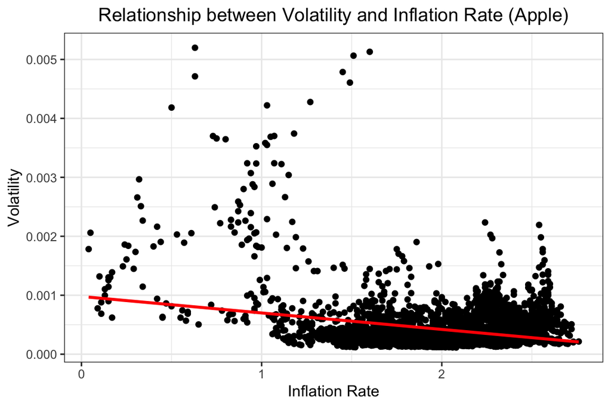

# 3.3.2 Unemployment Rate

The unemployment rate emerged as another influential factor, exhibiting significant coefficients for both companies. The updated equations, illustrating these findings, are presented below.

**Apple:**

$\sigma_t^2 = 0.102359(\epsilon_{t-1}^2) + 0.867087(\sigma_{t-1}^2) + (3.99 * 10^{-07})(x_{t-1}^2)$, having an average of residuals of $-0.00085$

**Google:**

$\sigma_t^2 = 0.077281(\epsilon_{t-1}^2) + 0.888856(\sigma_{t-1}^2) + 0.000001(x_{t-1}^2)$, having an average of residuals of $-0.00026$

To visualize the relationship, the figure for Apple below demonstrates that whenever there is a significant increase in the unemployment rate, the volatility tends to react in the same direction significantly.

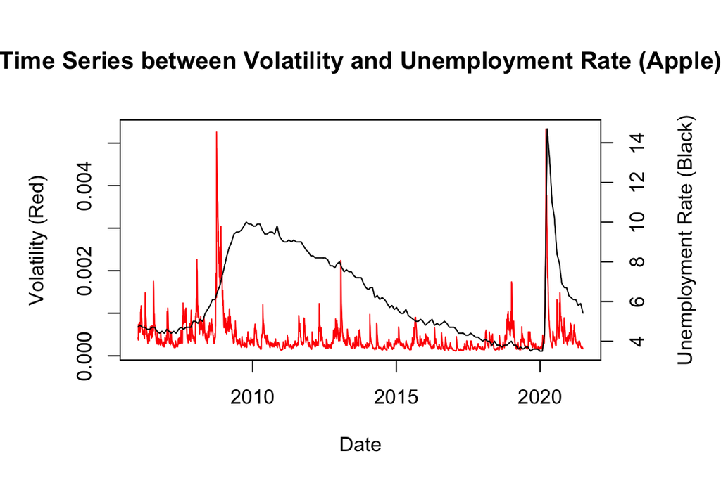

Similar to the approach employed for the inflation rate, an additional regression test will be conducted to investigate the correlation between volatility and the unemployment rate.

The results suggest that there is a statistically significant positive relationship between the unemployment rate and the volatility of the data. The coefficient estimate for the unemployment rate variable is 2.963e-05, which indicates that for each 1% increase in the unemployment rate, the volatility of the data increases by about 0.00002963 (or 0.002963%) units. The p-value associated with the coefficient is very small (< 2.2e-16), indicating that the coefficient is statistically significant. The R-squared value of 0.02171 suggests that the model explains only a small proportion of the variation in the data, but this is expected given the complexity of financial markets. Overall, the model provides evidence for a positive relationship between unemployment rate and volatility, suggesting that as the unemployment rate increases, the volatility of the data also tends to increase.

```
##
## Call:
## lm(formula = volatility ~ unemployment_rate, data = df)
##
## Residuals:
##        Min         1Q     Median         3Q        Max
## -0.0003822 -0.0002101 -0.0001191  0.0000626  0.0048264
##
## Coefficients:
##                    Estimate Std. Error t value Pr(>|t|)
## (Intercept)       2.410e-04  2.139e-05  11.267   <2e-16 ***
## unemployment_rate 2.963e-05  3.210e-06   9.229   <2e-16 ***
## ---
## Signif. codes:  0 '***' 0.001 '**' 0.01 '*' 0.05 '.' 0.1 ' ' 1
##
## Residual standard error: 0.0004279 on 3839 degrees of freedom
## Multiple R-squared:  0.02171,    Adjusted R-squared:  0.02145
## F-statistic: 85.18 on 1 and 3839 DF,  p-value: < 2.2e-16
```

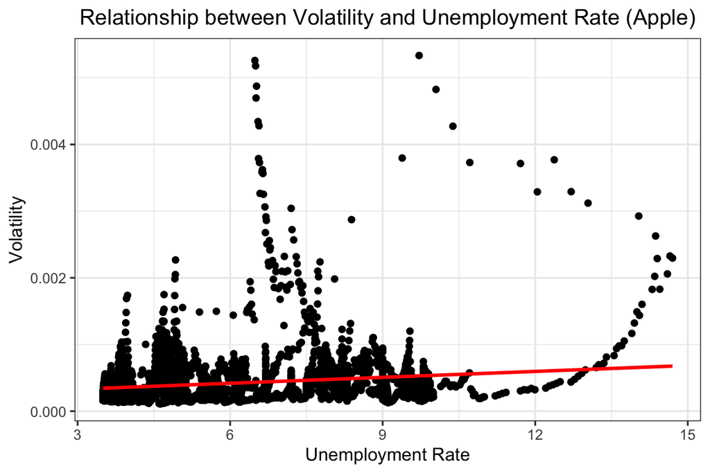

# 3.3.3 Interest Rate

The interest rate was found to exhibit significant coefficients, providing further evidence of its impact. The updated equations reflecting these outcomes are presented below.

**Apple:**

$\sigma_t^2 = 0.102957(\epsilon_{t-1}^2) + 0.863345(\sigma_{t-1}^2) + 0.000001(x_{t-1}^2)$, having an average of residuals of $-0.00084$

**Google:**

$\sigma_t^2 = 0.081589(\epsilon_{t-1}^2) + 0.884310(\sigma_{t-1}^2) + 0.000001(x_{t-1}^2)$, having an average of residuals of $-0.00025$

To visualize the relationship, the figure for Apple below demonstrates that whenever there is a significant decrease in the interest rate, the volatility tends to react in the opposite direction significantly.

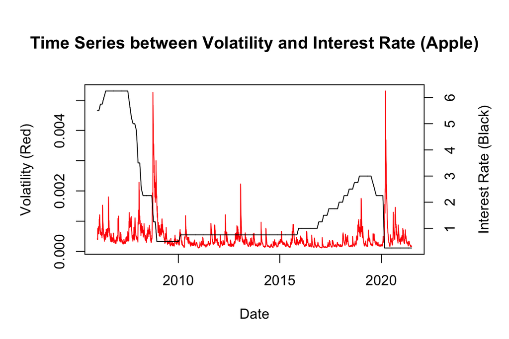

As before, another linear regression will be conducted to analyze the relationship between the interest rate and the volatility.

The results suggest that there is a statistically significant positive relationship between the interest rate and the volatility of the data. The coefficient estimate for the interest rate variable is 2.394e-05, which indicates that for each 1% increase in the interest rate, the volatility of the data increases by about 0.00002394 (or 0.002394%) units. The p-value associated with the coefficient is very small (7.697e-10), indicating that the coefficient is statistically significant. The R-squared value of 0.009808 suggests that the model explains only a small proportion of the variation in the data, but this is expected given the complexity of financial markets. Overall, the model provides evidence for a positive relationship between interest rate and volatility, suggesting that as the interest rate increases, the volatility of the data also tends to increase.

```
##
## Call:
## lm(formula = volatility ~ interest_rate, data = df)
##
## Residuals:
##        Min         1Q     Median         3Q        Max
## -0.0002993 -0.0002034 -0.0001171  0.0000428  0.0049127
##
## Coefficients:
##                Estimate Std. Error t value Pr(>|t|)
## (Intercept)   3.845e-04  9.694e-06  39.665  < 2e-16 ***
## interest_rate 2.394e-05  3.882e-06   6.167  7.7e-10 ***
## ---
## Signif. codes:  0 '***' 0.001 '**' 0.01 '*' 0.05 '.' 0.1 ' ' 1
##
## Residual standard error: 0.0004248 on 3839 degrees of freedom
## Multiple R-squared:  0.009808,   Adjusted R-squared:  0.00955
## F-statistic: 38.03 on 1 and 3839 DF,  p-value: 7.697e-10
```

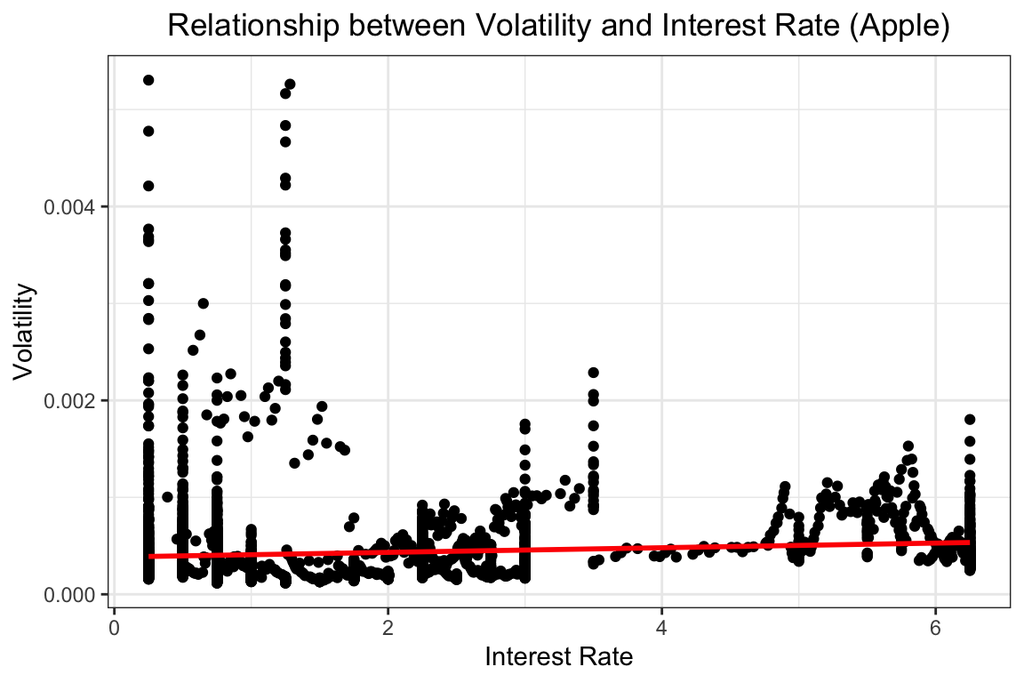